# Project on Iris Dataset

```r
summary(mod_sim)
```

```
Iterations = 2001:7000
Thinning interval = 1
Number of chains = 3
Sample size per chain = 5000

1. Empirical mean and standard deviation for each variable,
   plus standard error of the mean:

            Mean       SD  Naive SE Time-series SE
mu[1]    10.3551 0.179199 1.463e-03      2.998e-03
mu[2]    14.9546 0.276755 2.260e-03      8.238e-03
mu[3]    17.7770 0.393526 3.213e-03      1.142e-02
omega[1]  0.3724 0.040953 3.344e-04      4.603e-04
omega[2]  0.4037 0.062377 5.093e-04      1.835e-03
omega[3]  0.2239 0.059712 4.875e-04      1.918e-03
sig       1.1369 0.117679 9.608e-04      3.470e-03
z[1]      1.0003 0.016328 1.333e-04      1.333e-04
z[2]      1.0001 0.008165 6.667e-05      6.667e-05
z[3]      1.0001 0.011547 9.428e-05      9.428e-05
z[4]      1.0001 0.011547 9.428e-05      9.428e-05
z[5]      1.0004 0.019997 1.633e-04      1.633e-04
z[6]      1.0158 0.125239 1.023e-03      1.092e-03
z[7]      1.0001 0.008165 6.667e-05      6.667e-05
z[8]      1.0005 0.023089 1.885e-04      1.885e-04
z[9]      1.0000 0.000000 0.000e+00      0.000e+00
z[10]     1.0000 0.000000 0.000e+00      0.000e+00
z[11]     1.0024 0.048933 3.995e-04      4.248e-04
z[12]     1.0001 0.011547 9.428e-05      9.428e-05
z[13]     1.0001 0.008165 6.667e-05      6.667e-05
z[14]     1.0000 0.000000 0.000e+00      0.000e+00
z[15]     1.0078 0.087975 7.183e-04      7.679e-04
z[16]     1.1063 0.309354 2.526e-03      2.746e-03
z[17]     1.0053 0.072837 5.947e-04      5.947e-04
z[18]     1.0005 0.023089 1.885e-04      2.435e-04
z[19]     1.0217 0.146273 1.194e-03      1.252e-03
z[20]     1.0018 0.042390 3.461e-04      3.744e-04
z[21]     1.0023 0.049612 4.051e-04      4.306e-04
z[22]     1.0019 0.043929 3.587e-04      3.949e-04
z[23]     1.0001 0.008165 6.667e-05      6.667e-05
z[24]     1.0019 0.045421 3.709e-04      3.832e-04
```

[output cut: 272 more lines]

```
z[136]    3.0000  3.0000  3.0000  3.0000  3.0000
z[137]    2.0000  3.0000  3.0000  3.0000  3.0000
z[138]    2.0000  2.0000  3.0000  3.0000  3.0000
z[139]    2.0000  2.0000  2.0000  2.0000  3.0000
z[140]    2.0000  3.0000  3.0000  3.0000  3.0000
z[141]    2.0000  3.0000  3.0000  3.0000  3.0000
z[142]    2.0000  3.0000  3.0000  3.0000  3.0000
z[143]    2.0000  2.0000  2.0000  2.0000  3.0000
z[144]    2.0000  3.0000  3.0000  3.0000  3.0000
z[145]    2.0000  3.0000  3.0000  3.0000  3.0000
z[146]    2.0000  2.0000  3.0000  3.0000  3.0000
z[147]    2.0000  2.0000  2.0000  2.0000  3.0000
z[148]    2.0000  2.0000  3.0000  3.0000  3.0000
z[149]    2.0000  3.0000  3.0000  3.0000  3.0000
z[150]    2.0000  2.0000  2.0000  2.0000  3.0000
```

Convergence Analysis:

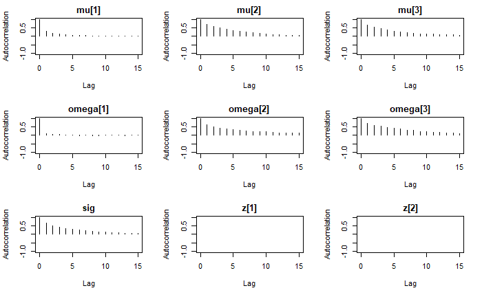

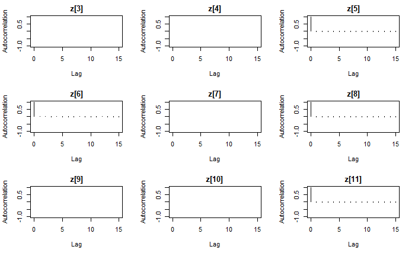

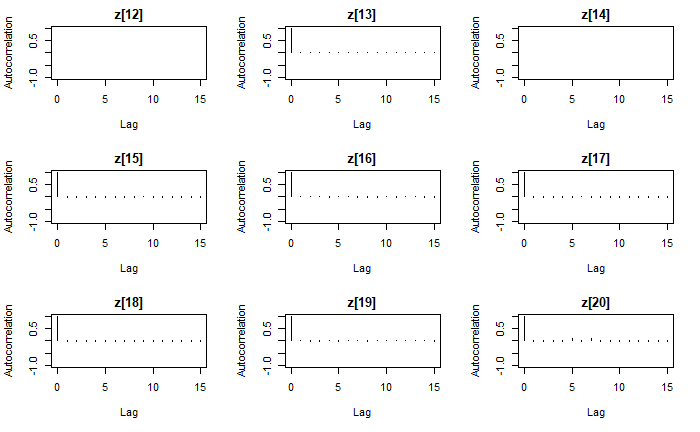

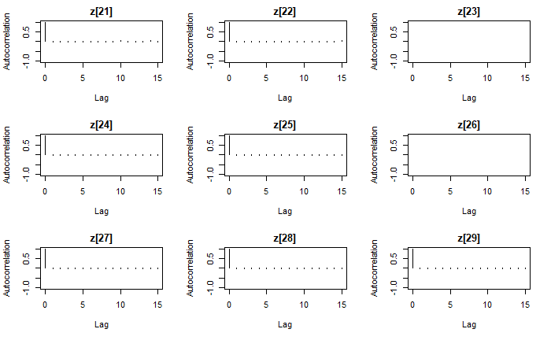

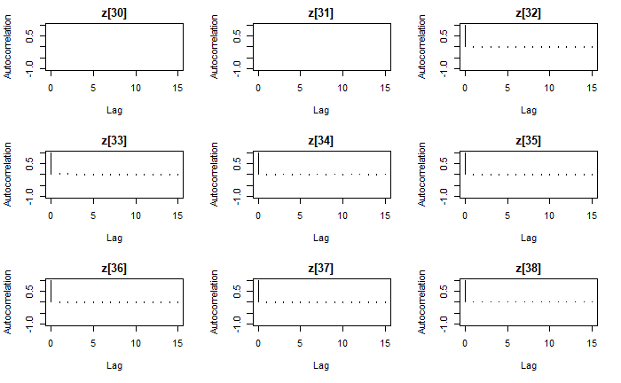

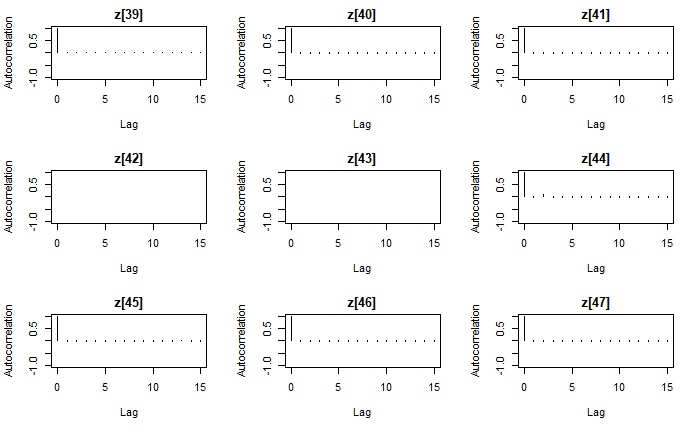

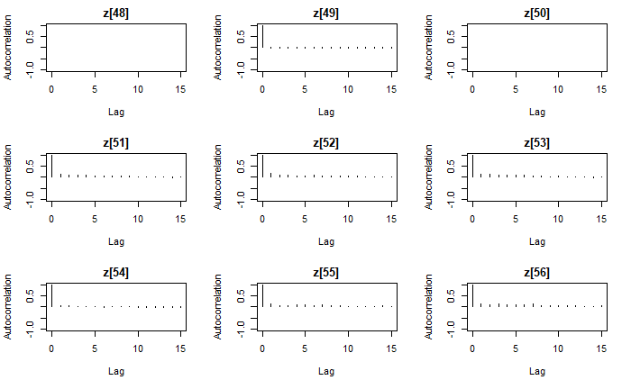

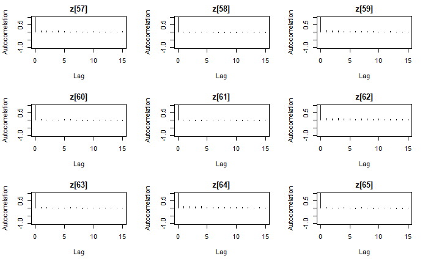

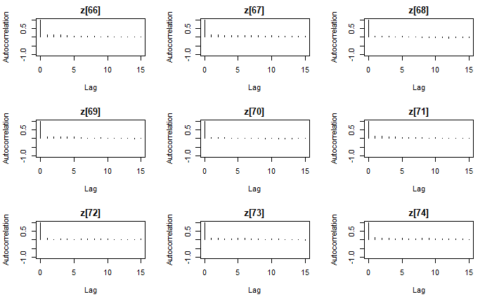

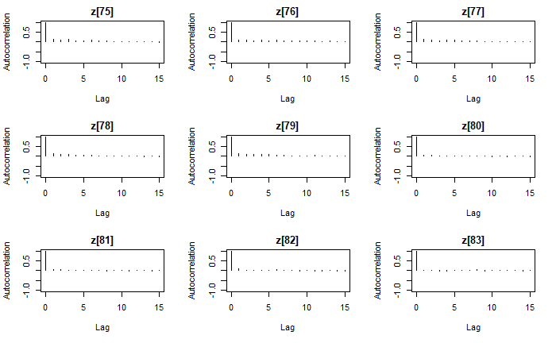

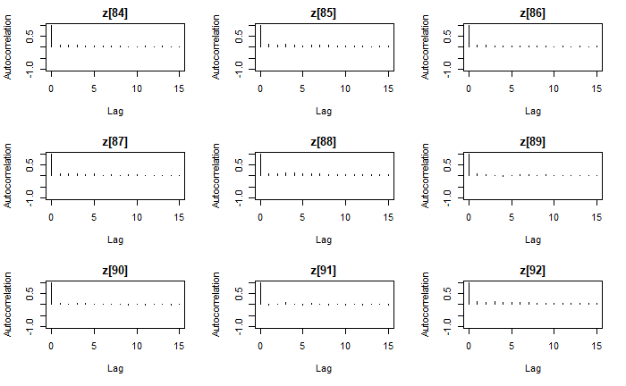

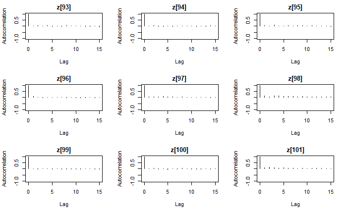

[41 more figures not shown]

```r
autocorr.plot(mod_sim)
```

```r
effectiveSize(mod_sim)
```

```
    mu[1]     mu[2]     mu[3]  omega[1]  omega[2]  omega[3]       sig      z[1]      z[2]      z[3]      z[4]      z[5]      z[6]      z[7]      z[8]      z[9]
 3767.632  1226.870  1387.224  8385.484  1183.456  1023.811  1234.295 10000.000  5000.000 10000.000 10000.000 15000.000 13182.573  5000.000 15000.000     0.000
    z[10]     z[11]     z[12]     z[13]     z[14]     z[15]     z[16]     z[17]     z[18]     z[19]     z[20]     z[21]     z[22]     z[23]     z[24]     z[25]
    0.000 13742.935 10000.000  5000.000     0.000 13417.519 12765.975 15000.000  9792.274 13639.563 13423.807 13615.081 12696.757  5000.000 14136.514 13819.778
    z[26]     z[27]     z[28]     z[29]     z[30]     z[31]     z[32]     z[33]     z[34]     z[35]     z[36]     z[37]     z[38]     z[39]     z[40]     z[41]
 5000.000 15000.000  8148.195 12932.921 10000.000 10000.000 15000.000 13328.835 14347.331 10000.000 11686.491 13931.295 15000.000  5000.000  8450.069 15000.000
    z[42]     z[43]     z[44]     z[45]     z[46]     z[47]     z[48]     z[49]     z[50]     z[51]     z[52]     z[53]     z[54]     z[55]     z[56]     z[57]
    0.000     0.000 13116.171 13437.428 10000.000 11654.404  5000.000 13041.157  5000.000  5360.730  4403.152  5818.036  9921.330  4598.567  4964.216  4657.754
    z[58]     z[59]     z[60]     z[61]     z[62]     z[63]     z[64]     z[65]     z[66]     z[67]     z[68]     z[69]     z[70]     z[71]     z[72]     z[73]
15000.000  5736.251  8896.901 13524.491  4754.952  9401.037  4008.668 10103.475  5544.622  3061.179  7817.820  4783.184  9253.750  5487.259  5741.518  4131.739
    z[74]     z[75]     z[76]     z[77]     z[78]     z[79]     z[80]     z[81]     z[82]     z[83]     z[84]     z[85]     z[86]     z[87]     z[88]     z[89]
 3652.636  6185.403  4148.312  5329.186  5317.812  3703.241  9199.175  9408.859  9367.203  9967.427  5285.138  5028.817  5165.481  5659.026  3596.011  6124.423
    z[90]     z[91]     z[92]     z[93]     z[94]     z[95]     z[96]     z[97]     z[98]     z[99]    z[100]    z[101]    z[102]    z[103]    z[104]    z[105]
 9943.097  7736.688  4062.362 11244.462 13255.273 10124.238  8380.620  5976.604  5976.555 13564.578  7507.593  3371.023  5495.259  3496.912  5600.989  4223.870
   z[106]    z[107]    z[108]    z[109]    z[110]    z[111]    z[112]    z[113]    z[114]    z[115]    z[116]    z[117]    z[118]    z[119]    z[120]    z[121]
 3317.924  9838.959  3030.272  5138.374  2432.336  4911.049  5495.536  4324.001  4417.554  5729.254  4838.308  4407.985  3361.045  3620.956  3949.216  3280.963
   z[122]    z[123]    z[124]    z[125]    z[126]    z[127]    z[128]    z[129]    z[130]    z[131]    z[132]    z[133]    z[134]    z[135]    z[136]    z[137]
 4867.855  3354.060  4763.485  4060.711  3232.691  5264.352  6027.075  4658.339  3426.409  2852.012  2860.570  4933.836  5478.041  5064.080  2396.272  3614.829
   z[138]    z[139]    z[140]    z[141]    z[142]    z[143]    z[144]    z[145]    z[146]    z[147]    z[148]    z[149]    z[150]
 4716.753  5461.929  4529.163  3762.247  3663.886  5462.262  3664.086  3263.297  4473.484  5445.512  4881.311  4231.135  5576.721
```

For the population parameters and the mixing weights:

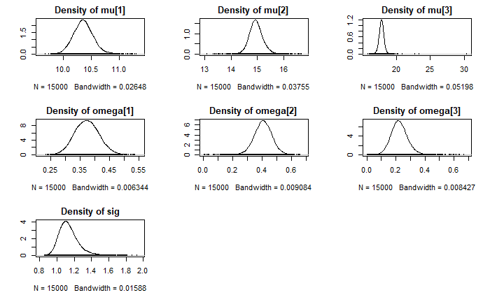

```r
par(mfrow = c(3,3))
densplot(mod_csim[,c("mu[1]","mu[2]","mu[3]","omega[1]","omega[2]","omega[3]","sig")])
```

```r
table(mod_csim[,"z[82]"])/nrow(mod_csim)
```

```
          1           2           3
0.525733333 0.473200000 0.001066667
```

# Hierarchical Modeling:

```r
mod_string_h = "model{
  for (i in 1:length(y)){
    y[i] ~ dnorm(mu[spec[i]],prec)
  }

  mu[1] ~ dnorm(-1,1.0/100.0)
  mu[2] ~ dnorm(0,1.0/100.0) T(mu[1],)
  mu[3] ~ dnorm(1, 1.0/100.0) T(mu[2],)

  prec ~ dgamma(1.0/2.0, 1.0*1.0/2.0)
  sig = sqrt(1.0/prec)

}"
```

```r
str(dat)
```

```
'data.frame':   150 obs. of  5 variables:
 $ Sepal.Length: num  5.1 4.9 4.7 4.6 5 5.4 4.6 5 4.4 4.9 ...
 $ Sepal.Width : num  3.5 3 3.2 3.1 3.6 3.9 3.4 3.4 2.9 3.1 ...
 $ Petal.Length: num  1.4 1.4 1.3 1.5 1.4 1.7 1.4 1.5 1.4 1.5 ...
 $ Petal.Width : num  0.2 0.2 0.2 0.2 0.2 0.4 0.3 0.2 0.2 0.1 ...
 $ Species     : Factor w/ 3 levels "setosa","versicolor",..: 1 1 1 1 1 1 1 1 1 1 ...
```

```r
spec = as.numeric(dat$Species)
```

```r
data_jags_h = list(y=y, spec = spec)
params = c("mu", "sig")

mod_h = jags.model(textConnection(mod_string_h),data = data_jags_h, n.chains = 3)
```

[output not shown]

```r
update(mod_h, 1e3)
```

[output not shown]

```r
mod_h_sim = coda.samples(model = mod_h, variable.names = params, n.iter = 5e3)
```

[output not shown]

```r
mod_h_csim = as.mcmc(do.call(rbind, mod_h_sim))
```

Convergence Diagnostics:

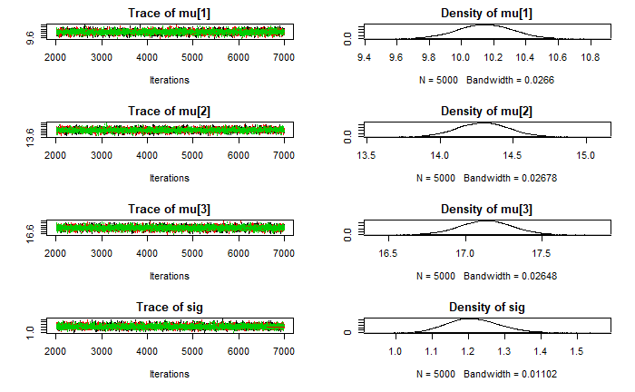

```r
plot(mod_h_sim)
```

```r
gelman.diag(mod_h_sim)
```

```
Potential scale reduction factors:

      Point est. Upper C.I.
mu[1]          1       1.00
mu[2]          1       1.01
mu[3]          1       1.00
sig            1       1.00

Multivariate psrf

1
```

```r
effectiveSize(mod_h_sim)
```

```
    mu[1]     mu[2]     mu[3]       sig
 8996.951  8943.544 15740.434 13588.590
```

```r
(dic_h = dic.samples(mod_h, n.iter = 1e3))
```

[output not shown]

```r
(dic_mm = dic.samples(mod, n.iter = 1e3))
```

[output not shown]

Summary of the model:

```r
summary(mod_h_sim)
```

```
Iterations = 2001:7000
Thinning interval = 1
Number of chains = 3
Sample size per chain = 5000

1. Empirical mean and standard deviation for each variable,
   plus standard error of the mean:

        Mean      SD  Naive SE Time-series SE
mu[1] 10.144 0.17172 0.0014021      0.0018112
mu[2] 14.294 0.17288 0.0014116      0.0018286
mu[3] 17.135 0.17125 0.0013982      0.0013660
sig    1.216 0.07112 0.0005807      0.0006121

2. Quantiles for each variable:

        2.5%    25%    50%    75%  97.5%
mu[1]  9.803 10.030 10.145 10.261 10.481
mu[2] 13.956 14.176 14.295 14.410 14.634
mu[3] 16.795 17.020 17.134 17.249 17.472
sig    1.088  1.166  1.212  1.262  1.363
```

#### Model Checking:

We can check the fit via residuals. With hierarchical model, there are now two levels of residuals: the observation level and the location mean level. To simplify, we’ll look at the residuals associcated with the posterior means of the parameters.

```r
(pm_coeff_h = colMeans(mod_h_csim))
```

```
   mu[1]    mu[2]    mu[3]      sig
10.14424 14.29386 17.13497  1.21590
```

```r
summary(mod_h_csim)
```

```
Iterations = 1:15000
Thinning interval = 1
Number of chains = 1
Sample size per chain = 15000

1. Empirical mean and standard deviation for each variable,
   plus standard error of the mean:

        Mean      SD  Naive SE Time-series SE
mu[1] 10.144 0.17172 0.0014021      0.0017838
mu[2] 14.294 0.17288 0.0014116      0.0018175
mu[3] 17.135 0.17125 0.0013982      0.0013622
sig    1.216 0.07112 0.0005807      0.0005947

2. Quantiles for each variable:

        2.5%    25%    50%    75%  97.5%
mu[1]  9.803 10.030 10.145 10.261 10.481
mu[2] 13.956 14.176 14.295 14.410 14.634
mu[3] 16.795 17.020 17.134 17.249 17.472
sig    1.088  1.166  1.212  1.262  1.363
```

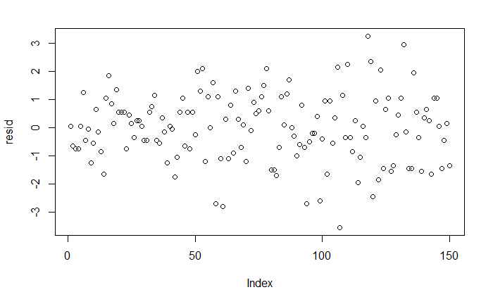

```r
yhat = rep(pm_coeff_h[1:3],each = 50)

resid = y - yhat
plot(resid)
```

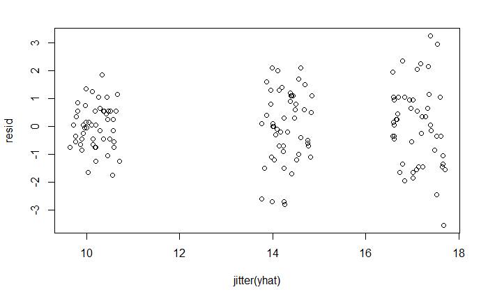

```r
plot(jitter(yhat),resid)
```

```r
(n_sim = nrow(mod_h_csim))
```

```
[1] 15000
```

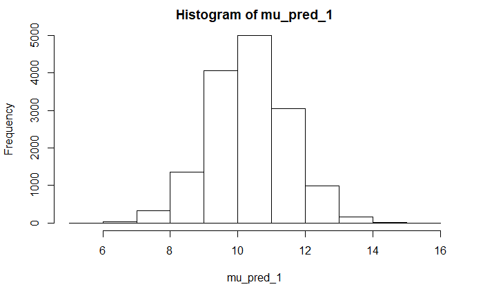

```r
mu_pred_1 = rnorm(n=n_sim, mean = mod_csim[,"mu[1]"],sd = mod_csim[,"sig"])
hist(mu_pred_1)
```

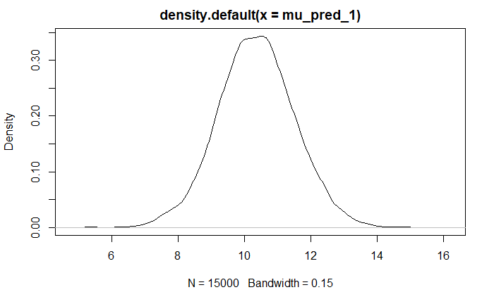

```r
plot(density(mu_pred_1))
```

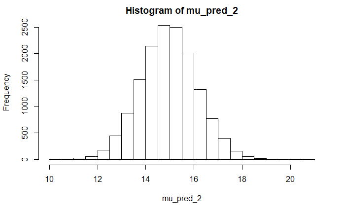

```r
mu_pred_2 = rnorm(n=n_sim, mean = mod_csim[,"mu[2]"],sd = mod_csim[,"sig"])
hist(mu_pred_2)
```

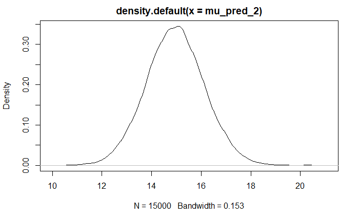

```r
plot(density(mu_pred_2))
```

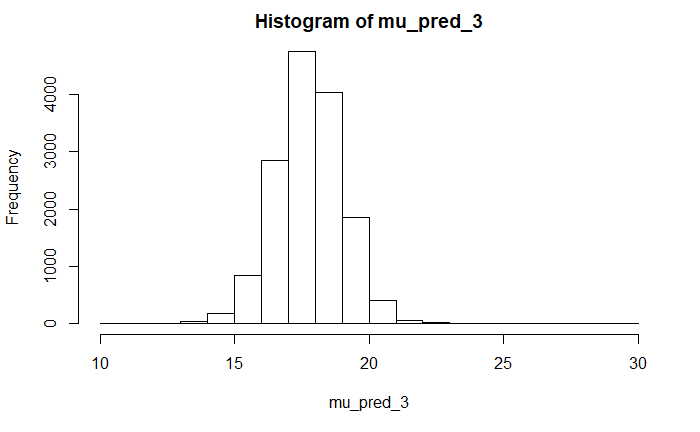

```r
mu_pred_3 = rnorm(n=n_sim, mean = mod_csim[,"mu[3]"],sd = mod_csim[,"sig"])
hist(mu_pred_3)
```

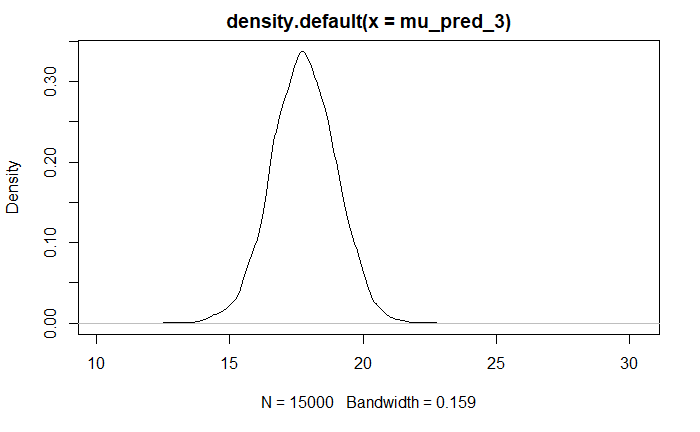

```r
plot(density(mu_pred_3))
```

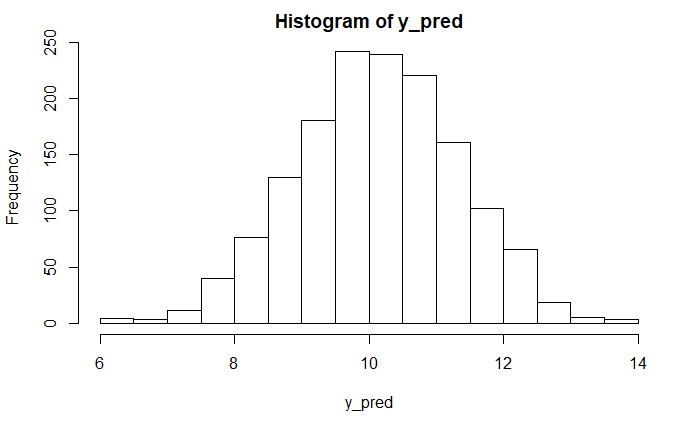

```r
y_pred = rnorm(n = 1500, mean = pm_coeff_h[1],sd = pm_coeff_h[4])
hist(y_pred)
```

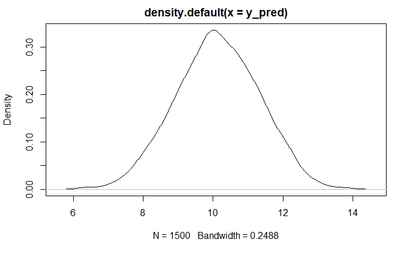

```r
plot(density(y_pred))
```

What is the posterior probability that the next value would correspond to species 3?

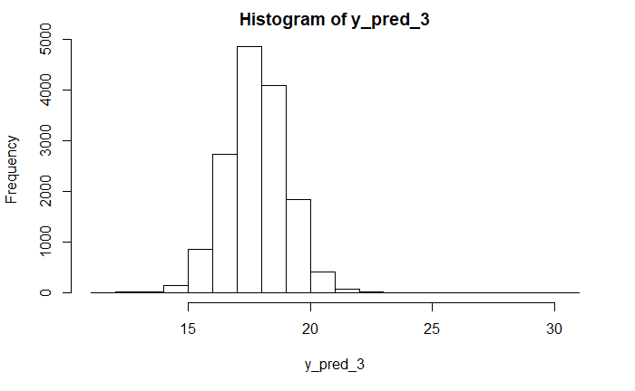

```r
y_pred_3 = rnorm(n = n_sim, mean = mod_csim[,"mu[3]"],sd = mod_csim[,"sig"])
hist(y_pred_3)
```

```r
mean(y_pred_3<17)
```

```
[1] 0.2505333
```

# Multinomial Logistic Regression:

```r
library("nnet")
model_lr = multinom(Species ~ Sepal.Length + Sepal.Width + Petal.Length + Petal.Width , data = dat)
```

```r
summary(model_lr)
```

```
Call:
multinom(formula = Species ~ Sepal.Length + Sepal.Width + Petal.Length +
    Petal.Width, data = dat)

Coefficients:
           (Intercept) Sepal.Length Sepal.Width Petal.Length Petal.Width
versicolor    18.69037    -5.458424   -8.707401     14.24477   -3.097684
virginica    -23.83628    -7.923634  -15.370769     23.65978   15.135301

Std. Errors:
           (Intercept) Sepal.Length Sepal.Width Petal.Length Petal.Width
versicolor    34.97116     89.89215    157.0415     60.19170    45.48852
virginica     35.76649     89.91153    157.1196     60.46753    45.93406

Residual Deviance: 11.89973
AIC: 31.89973
```

```r
X = model.matrix(model_lr)
head(X[,c(2:5)])
```

```
  Sepal.Length Sepal.Width Petal.Length Petal.Width
1          5.1         3.5          1.4         0.2
2          4.9         3.0          1.4         0.2
3          4.7         3.2          1.3         0.2
4          4.6         3.1          1.5         0.2
5          5.0         3.6          1.4         0.2
6          5.4         3.9          1.7         0.4
```

```r
(coefs = coef(model_lr))
```

```
           (Intercept) Sepal.Length Sepal.Width Petal.Length Petal.Width
versicolor    18.69037    -5.458424   -8.707401     14.24477   -3.097684
virginica    -23.83628    -7.923634  -15.370769     23.65978   15.135301
```

```r
log_Pph21 = coefs[1,1] + X[,c(2:5)] %*% coefs[1,2:5]      # eta_2
log_Pph31 = coefs[2,1] + X[,c(2:5)] %*% coefs[2,2:5]      # eta_3
```

```r
phi2 = exp(log_Pph21)/(1+exp(log_Pph21)+exp(log_Pph31))
phi3 = exp(log_Pph31)/(1+exp(log_Pph21)+exp(log_Pph31))
phi1 = 1/(1+exp(log_Pph21)+exp(log_Pph31))
Species_1 = phi1[1:50]>0.7 & phi1[1:50]<1
table(Species_1)
```

```
Species_1
TRUE
  50
```

```r
Species_2 = phi2[51:100]>0.7 & phi1[51:100]<1
table(Species_2)
```

```
Species_2
FALSE  TRUE
    2    48
```

```r
Species_3 = phi3[101:150]>0.7 & phi1[101:150]<1
table(Species_3)
```

```
Species_3
FALSE  TRUE
    2    48
```